# Report COVID study SE 103

Thijs de Boer

2021

Last update: 2021-01-27 16:36:39

```r
load("C:/Users/Thijs/surfdrive/COVID vaccine/R data/git/SE/.RData")

set_theme(
  base=theme_blank(),
  geom.outline.size = 0.01,
  geom.outline.color = "white",
  geom.label.size = 3,
  geom.label.color = "grey50")
```

# 1 Population

Total number of participants:

```r
df.total %>% nrow()
```

```
## [1] 682
```

Number of participants that failed the attention test:

```r
df.total %>% nrow() - df.total %>% filter(IMC=="1") %>% nrow()
```

```
## [1] 184
```

Participants between 0-17:

```r
df.total %>% filter(age < 18) %>% nrow()
```

```
## [1] 0
```

Percentage of participants who are at least 18 years old and did not fail the IMC:

```r
percent((df.def %>% nrow() / df.total %>% nrow()))
```

```
## [1] "73%"
```

Number of participants in this analysis:

```r
df.def %>% nrow()
```

```
## [1] 498
```

Number of participants in the final dataset that failed the manipulation check:

```r
df.def %>% nrow() - df.def %>% filter(manipulation.check=="1") %>% nrow()
```

```
## [1] 153
```

Which is:

```r
percent(df.def %>% filter(manipulation.check!="1") %>% nrow() / df.def %>% nrow(), accuracy = 0.01)
```

```
## [1] "30.72%"
```

# 2 Experiment: Perceived independence of EMA

## 2.1 Randomisation check

This table shows how many respondents are assigned to each experimental group.

```r
df.def %>%
  group_by(experimental.group) %>%
  tally()
```

```
## # A tibble: 2 x 2
##   experimental.group     n
##   <chr>              <int>
## 1 control              250
## 2 treatment            248
```

## 2.2 Description

```r
df.def %>%
sjmisc::descr(perceived.independence.reversed, show = c("n", "NA.prc", "mean", "sd", "md", "iqr", "trimmed", "range", "skew")) %>%
  kbl(digits= 2) %>%
 kable_paper()
```

| var | n | NA.prc | mean | sd | md | trimmed | range | iqr | skew |
| --- | --- | --- | --- | --- | --- | --- | --- | --- | --- |
| perceived.independence.reversed | 498 | 0 | 3.19 | 1.39 | 3 | 3.12 | 6 (1-7) | 2 | 0.53 |

## 2.3 Histogram

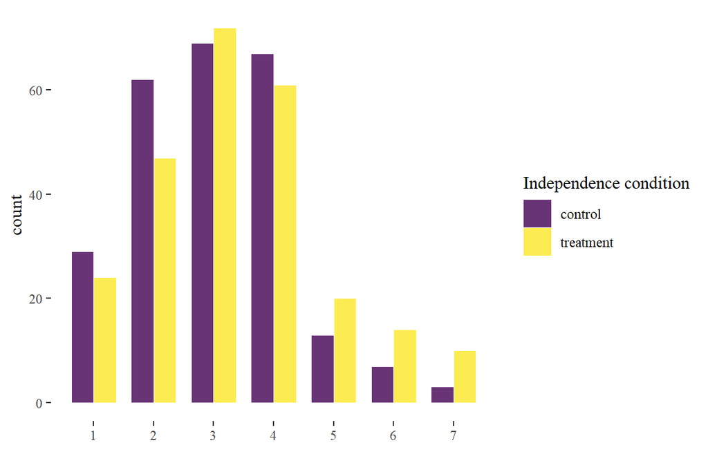

```r
df.def %>%
  ggplot(aes(x = perceived.independence.reversed, fill = experimental.group)) +
  geom_bar(width = 0.75,alpha = 0.8, position = position_dodge()) +
  scale_x_continuous(name="", breaks = 1:7) + scale_fill_manual(name = "Independence condition") +  scale_fill_viridis_d(name = "Independence condition") +
  theme_tufte()
```

## 2.4 T-test

### 2.4.1 With complete dataset

```r
tadaa_t.test(data = df.def, response = perceived.independence.reversed, group = experimental.group, print = "markdown")
```

Table 1: **Welch Two Sample t-test** with alternative hypothesis: $\mu_1 \neq \mu_2$

| Diff | $\mu_1$ control | $\mu_2$ treatment | t | SE | df | $CI_{95\%}$ | p | Cohen's d |
| --- | --- | --- | --- | --- | --- | --- | --- | --- |
| -0.33 | 3.02 | 3.35 | -2.67 | 0.12 | 485.05 | (-0.57 - -0.09) | < .01 | -0.24 |

### 2.4.2 With those who failed the manipulation check filtered out

```r
tadaa_t.test(data = df.check, response = perceived.independence.reversed, group = experimental.group, print = "markdown")
```

Table 2: **Welch Two Sample t-test** with alternative hypothesis: $\mu_1 \neq \mu_2$

| Diff | $\mu_1$ control | $\mu_2$ treatment | t | SE | df | $CI_{95\%}$ | p | Cohen's d |
| --- | --- | --- | --- | --- | --- | --- | --- | --- |
| -0.49 | 2.99 | 3.48 | -3.11 | 0.16 | 285.45 | (-0.8 - -0.18) | < .01 | -0.35 |

# 3 Time

## 3.1 Survey duration

### 3.1.1 Histogram

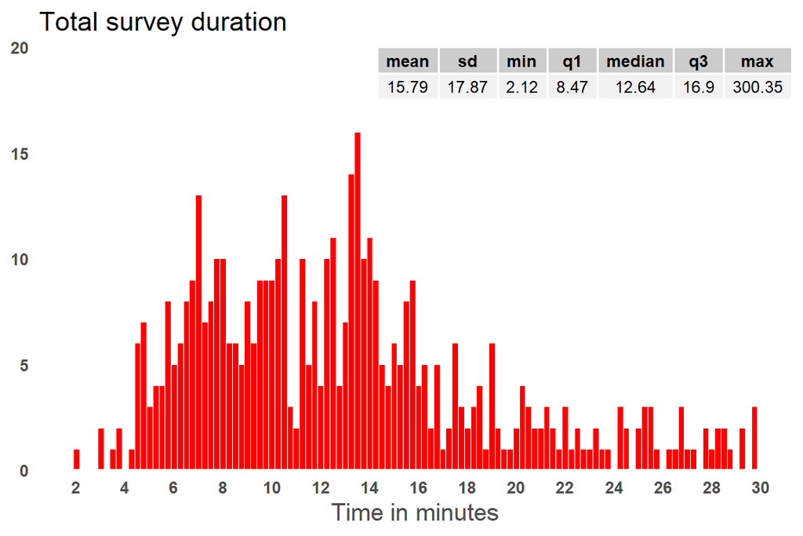

```r
df.def %>% filter(duration < 30) %>%
plot_frq((duration),
        geom.colors = alpha("red",0.8),
        type = "hist",
        geom.size = 0.25) +
  theme(axis.text = element_text(face = "bold",  size= 9)) + labs(title = "Total survey duration") +  scale_x_continuous(name="Time in minutes", breaks = seq(0,30, 2)) +  scale_y_continuous(expand = expansion(c(0, 0.25))) + annotate(geom = "table", x = Inf, y = Inf, label = list(table.duration))
```

### 3.1.2 Relationship between perceived independence and total survey duration

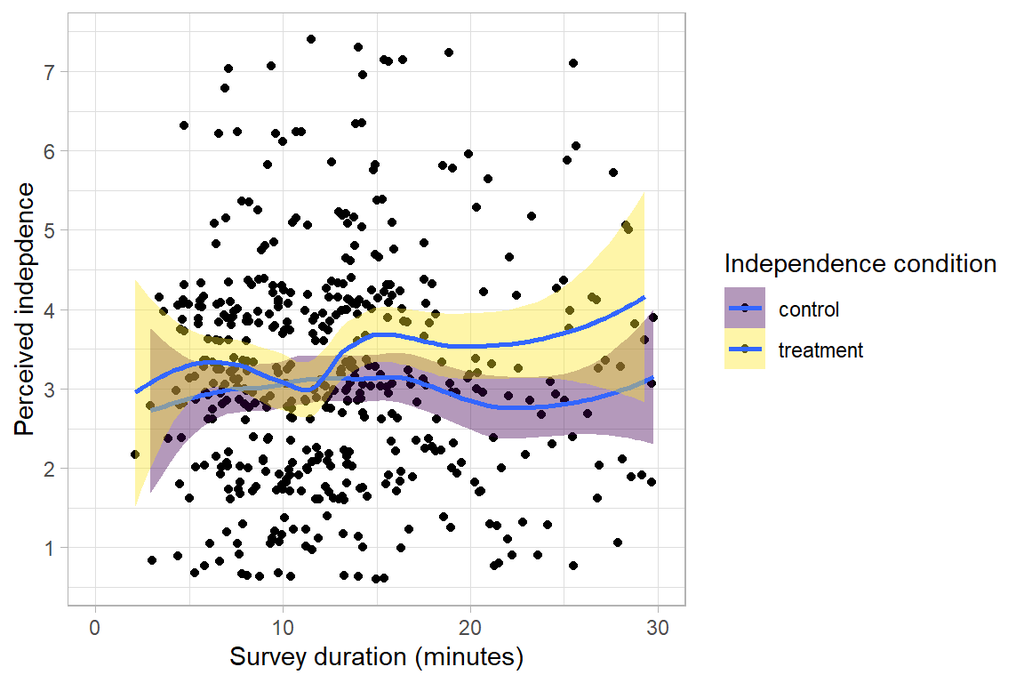

```r
df.def %>% filter(duration < 30) %>% ggplot(aes(duration, perceived.independence.reversed, fill = experimental.group)) + geom_jitter() + geom_smooth() + scale_x_continuous("Survey duration (minutes)", limits = c(0,30)) + scale_y_continuous("Perceived indepdence", breaks = 1:7) + scale_fill_viridis_d(name = "Independence condition") + theme_light()
```

## 3.2 Do participants read the information about the case?

### 3.2.1 Page submission - introduction of case

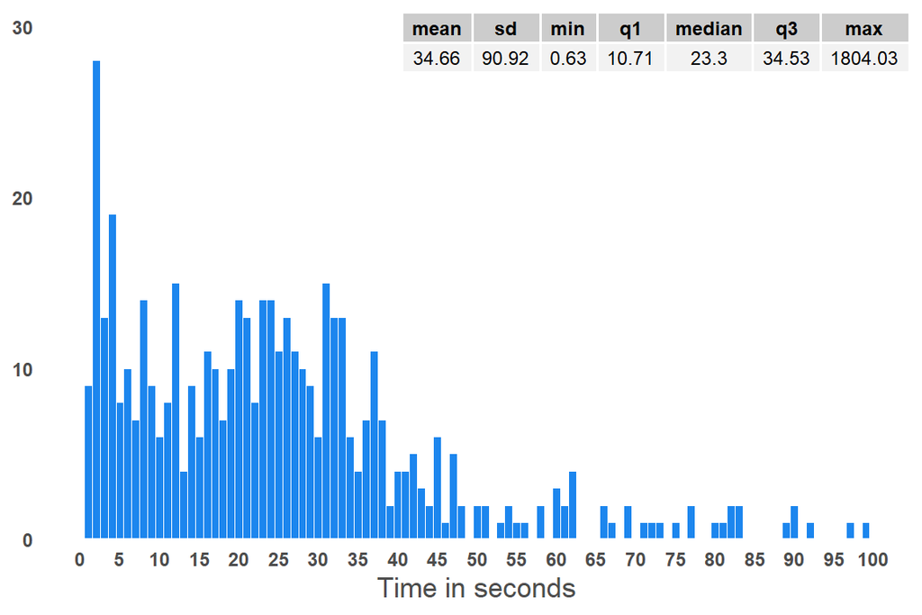

```r
df.def %>% filter(intro.submit < 100) %>%
plot_frq((intro.submit),
        geom.colors = alpha("dodgerblue2",0.8),
        type = "hist",
        geom.size = 1) +
  theme(axis.text = element_text(face = "bold",  size= 9)) +
  scale_x_continuous(name="Time in seconds",breaks = seq(0,100,5)) +   scale_y_continuous(expand = expansion(c(0, 0.1))) + annotate(geom = "table", x = Inf, y = Inf, label = list(table.intro.submit))
```

### 3.2.2 Page submission - manipulation

*Histogram*

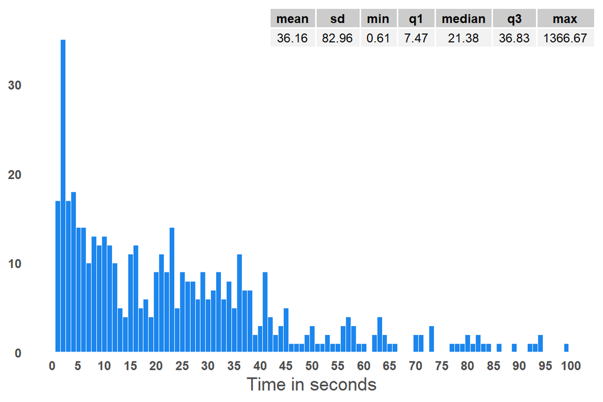

```r
df.def %>% filter(manipulation.submit < 100) %>%
plot_frq((manipulation.submit),
        geom.colors = alpha("dodgerblue2",0.8),
        type = "hist",
        geom.size = 1) +
  theme(axis.text = element_text(face = "bold",  size= 9)) +
  scale_x_continuous(name="Time in seconds",breaks = seq(0,100,5)) +   scale_y_continuous(expand = expansion(c(0, 0.1))) + annotate(geom = "table", x = Inf, y = Inf, label = list(table.manipulation.submit))
```

*Relationship between perceived independence and time spent on the page with the manipulation*

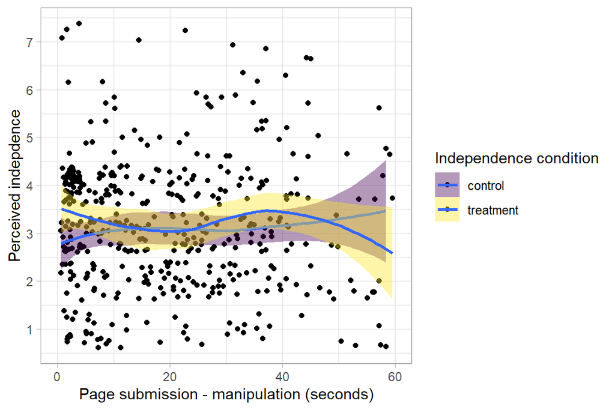

```r
df.def %>% filter(manipulation.submit < 60) %>% ggplot(aes(manipulation.submit, perceived.independence.reversed, fill = experimental.group)) + geom_jitter() + geom_smooth() + scale_x_continuous("Page submission - manipulation (seconds)", limits = c(0,60)) + scale_y_continuous("Perceived indepdence", breaks = 1:7) + scale_fill_viridis_d(name = "Independence condition") + theme_light()
```

*Broken down in quartiles (+ group size and SE)*

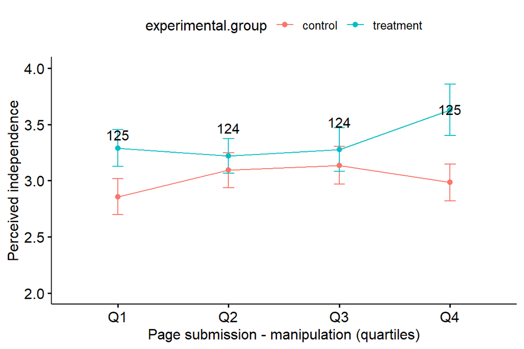

```r
give.n <- function(x){
  return(c(y = mean(x)*1.1, label = length(x)))
}

ggline(df.def, x = "manipulation.submit.quartile", y = "perceived.independence.reversed", color = "experimental.group", ylab = "Perceived independence", xlab = "Page submission - manipulation (quartiles)",  add = "mean_se", ylim = c(2, 4), yticks.by = 0.5) +
  stat_summary(fun.data = give.n, geom = "text", fun = median, size = 4, col = "black")
```

*Split dataset with 30 seconds as cut-off point (+ group size and SE)*

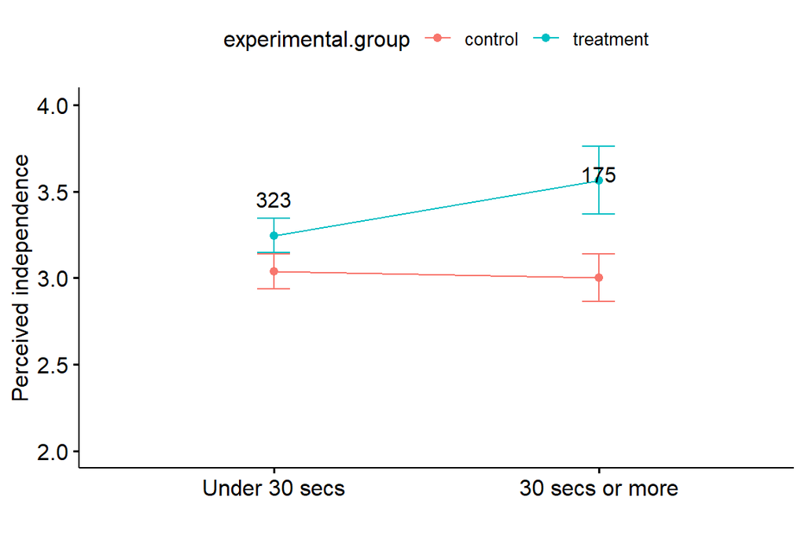

```r
ggline(df.def, x = "manipulation.submit.30", y = "perceived.independence.reversed", color = "experimental.group", ylab = "Perceived independence", xlab = "",  add = c("mean_se"), ylim = c(2, 4), yticks.by = 0.5) +
  stat_summary(fun.data = give.n, geom = "text", fun = median, size = 4, col = "black")
```

### 3.2.3 Page submission - EMA’s decision

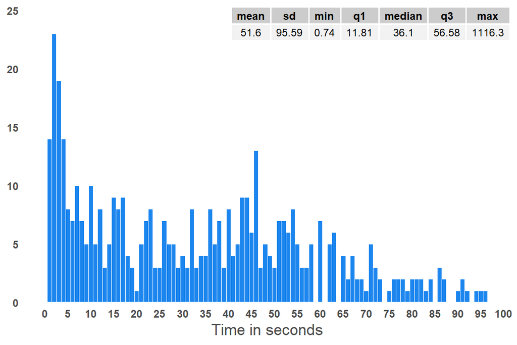

```r
df.def %>% filter(decision.submit < 100) %>%
plot_frq((decision.submit),
        geom.colors = alpha("dodgerblue2",0.8),
        type = "hist",
        geom.size = 1) +
  theme(axis.text = element_text(face = "bold",  size= 9)) +
  scale_x_continuous(name= "Time in seconds", breaks = seq(0,100,5)) +   scale_y_continuous(expand = expansion(c(0, 0.1))) + annotate(geom = "table", x = Inf, y = Inf, label = list(table.decision.submit))
```

### 3.2.4 Time and …

*…Failing the manipulation check*

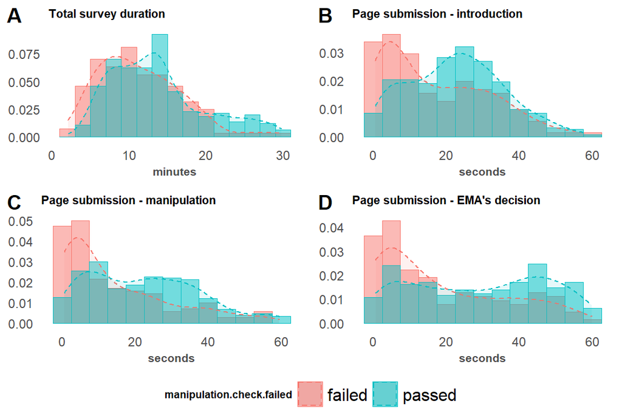

```r
p1 <- df.def %>% filter(duration < 30) %>% ggplot(aes(x= duration, color = manipulation.check.failed, fill = manipulation.check.failed)) + geom_histogram(aes(y=..density..), alpha=0.5, position="identity", binwidth = 2) +
 geom_density(alpha= .1, linetype= "dashed") + labs(title = "Total survey duration", x = "minutes") + theme(axis.title.y = element_blank(), title = element_text(size = 7, face = "bold"),  axis.text = element_text(size = 9))

p2  <- df.def %>% filter(intro.submit < 60) %>% ggplot(aes(x= intro.submit, color = manipulation.check.failed, fill = manipulation.check.failed)) + geom_histogram(aes(y=..density..), alpha=0.5, position="identity", binwidth = 5) +
 geom_density(alpha= .1, linetype= "dashed") + labs(title = "Page submission - introduction", x = "seconds") + theme(axis.title.y = element_blank(), title = element_text(size = 7, face = "bold"),  axis.text = element_text(size = 9))

p3 <- df.def %>% filter(manipulation.submit < 60) %>% ggplot(aes(x=manipulation.submit, color = manipulation.check.failed, fill = manipulation.check.failed)) + geom_histogram(aes(y=..density..), alpha=0.5, position="identity", binwidth = 5) + geom_density(alpha= .1, linetype= "dashed") + labs(title = "Page submission - manipulation", x = "seconds") + theme(axis.title.y = element_blank(), title = element_text(size = 7, face = "bold"),  axis.text = element_text(size = 9))

p4 <- df.def %>% filter(decision.submit < 60) %>% ggplot(aes(x=decision.submit, color =manipulation.check.failed, fill = manipulation.check.failed)) +
 geom_histogram(aes(y=..density..), alpha=0.5, position="identity", binwidth = 5) +
 geom_density(alpha= .1, linetype= "dashed") + labs(title = "Page submission - EMA's decision", x = "seconds", color = "Manipulation Check") + theme(axis.title.y = element_blank(), title = element_text(size = 7, face = "bold"),  axis.text = element_text(size = 9))

ggarrange(p1, p2, p3, p4, nrow = 2, ncol = 2, labels="AUTO", legend = "bottom", common.legend = TRUE)
```

*…experimental groups*

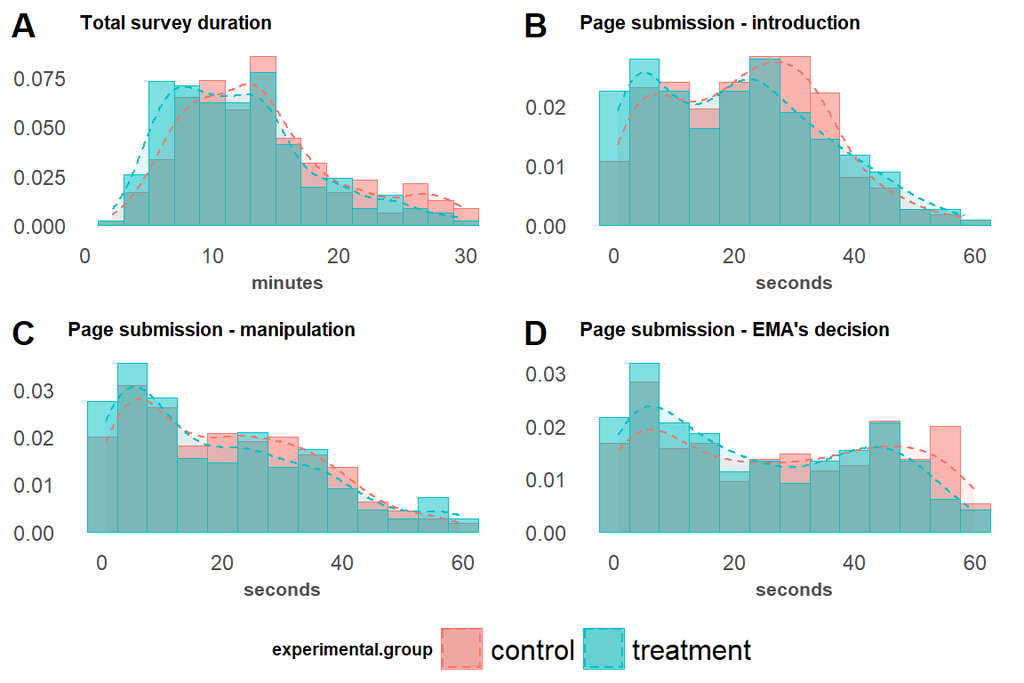

```r
p5 <- df.def %>% filter(duration < 30) %>% ggplot(aes(x= duration, color = experimental.group, fill = experimental.group)) + geom_histogram(aes(y=..density..), alpha=0.5, position="identity", binwidth = 2) +
 geom_density(alpha= .1, linetype= "dashed") + labs(title = "Total survey duration", x = "minutes") + theme(axis.title.y = element_blank(), title = element_text(size = 7, face = "bold"),  axis.text = element_text(size = 9))

p6  <- df.def %>% filter(intro.submit < 60) %>% ggplot(aes(x= intro.submit, color = experimental.group, fill = experimental.group)) + geom_histogram(aes(y=..density..), alpha=0.5, position="identity", binwidth = 5) +
 geom_density(alpha= .1, linetype= "dashed") + labs(title = "Page submission - introduction", x = "seconds") + theme(axis.title.y = element_blank(), title = element_text(size = 7, face = "bold"),  axis.text = element_text(size = 9))

p7 <- df.def %>% filter(manipulation.submit < 60) %>% ggplot(aes(x=manipulation.submit, color = experimental.group, fill = experimental.group)) + geom_histogram(aes(y=..density..), alpha=0.5, position="identity", binwidth = 5) + geom_density(alpha= .1, linetype= "dashed") + labs(title = "Page submission - manipulation", x = "seconds") + theme(axis.title.y = element_blank(), title = element_text(size = 7, face = "bold"),  axis.text = element_text(size = 9))

p8 <- df.def %>% filter(decision.submit < 60) %>% ggplot(aes(x=decision.submit, color = experimental.group, fill = experimental.group)) +
 geom_histogram(aes(y=..density..), alpha=0.5, position="identity", binwidth = 5) +
 geom_density(alpha= .1, linetype= "dashed") + labs(title = "Page submission - EMA's decision", x = "seconds", color = "Manipulation Check") + theme(axis.title.y = element_blank(), title = element_text(size = 7, face = "bold"),  axis.text = element_text(size = 9))

ggarrange(p5, p6, p7, p8, nrow = 2, ncol = 2, labels="AUTO", legend = "bottom", common.legend = TRUE)
```

T-tests (outliers removed - i.e., cases outside 1.5 times the interquartile range):

*Survey duration*

```r
tadaa_t.test(data = out.duration, response = duration, group = experimental.group, print = "markdown")
```

Table 3: **Welch Two Sample t-test** with alternative hypothesis: $\mu_1 \neq \mu_2$

| Diff | $\mu_1$ control | $\mu_2$ treatment | t | SE | df | $CI_{95\%}$ | p | Cohen's d |
| --- | --- | --- | --- | --- | --- | --- | --- | --- |
| 1.41 | 13.56 | 12.15 | 2.63 | 0.54 | 464.84 | (0.36 - 2.47) | < .01 | 0.24 |

*Page submission - Introduction*

```r
tadaa_t.test(data = out.intro.submit, response = intro.submit, group = experimental.group, print = "markdown")
```

Table 4: **Welch Two Sample t-test** with alternative hypothesis: $\mu_1 \neq \mu_2$

| Diff | $\mu_1$ control | $\mu_2$ treatment | t | SE | df | $CI_{95\%}$ | p | Cohen's d |
| --- | --- | --- | --- | --- | --- | --- | --- | --- |
| 0.97 | 22.89 | 21.92 | 0.68 | 1.42 | 453.3 | (-1.82 - 3.75) | .495 | 0.06 |

*Page submission - manipulation*

```r
tadaa_t.test(data = out.manipulation.submit, response = manipulation.submit, group = experimental.group, print = "markdown")
```

Table 5: **Welch Two Sample t-test** with alternative hypothesis: $\mu_1 \neq \mu_2$

| Diff | $\mu_1$ control | $\mu_2$ treatment | t | SE | df | $CI_{95\%}$ | p | Cohen's d |
| --- | --- | --- | --- | --- | --- | --- | --- | --- |
| 0.42 | 22.54 | 22.12 | 0.24 | 1.72 | 456.38 | (-2.96 - 3.79) | .809 | 0.02 |

*Page submission - decision*

```r
tadaa_t.test(data = out.decision.submit, response = decision.submit, group = experimental.group, print = "markdown")
```

Table 6: **Welch Two Sample t-test** with alternative hypothesis: $\mu_1 \neq \mu_2$

| Diff | $\mu_1$ control | $\mu_2$ treatment | t | SE | df | $CI_{95\%}$ | p | Cohen's d |
| --- | --- | --- | --- | --- | --- | --- | --- | --- |
| 4.38 | 38.12 | 33.74 | 1.67 | 2.62 | 467.89 | (-0.76 - 9.52) | .095 | 0.15 |

*…interface (pc/mobile)*

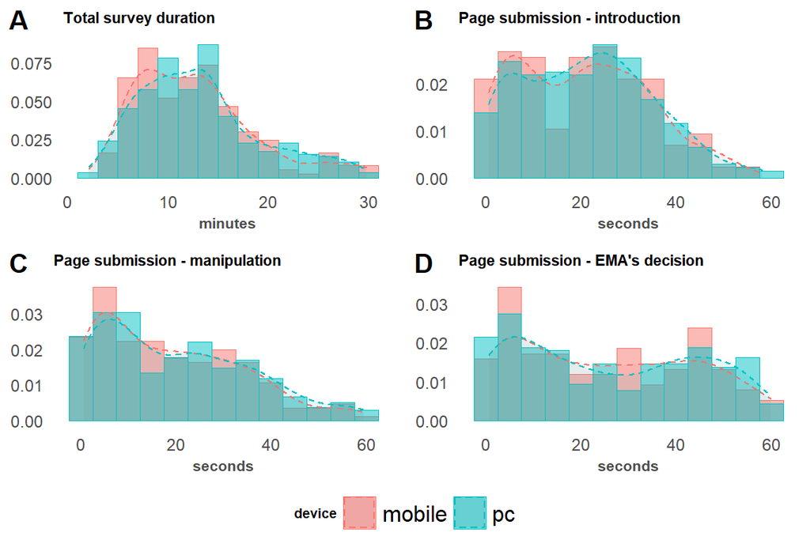

```r
p9 <- df.def %>% filter(duration < 30) %>% ggplot(aes(x= duration, color = device, fill = device)) + geom_histogram(aes(y=..density..), alpha=0.5, position="identity", binwidth = 2) +
 geom_density(alpha= .1, linetype= "dashed") + labs(title = "Total survey duration", x = "minutes") + theme(axis.title.y = element_blank(), title = element_text(size = 7, face = "bold"),  axis.text = element_text(size = 9))

p10 <- df.def %>% filter(intro.submit < 60) %>% ggplot(aes(x= intro.submit, color = device, fill = device)) + geom_histogram(aes(y=..density..), alpha=0.5, position="identity", binwidth = 5) +
 geom_density(alpha= .1, linetype= "dashed") + labs(title = "Page submission - introduction", x = "seconds") + theme(axis.title.y = element_blank(), title = element_text(size = 7, face = "bold"),  axis.text = element_text(size = 9))

p11 <- df.def %>% filter(manipulation.submit < 60) %>% ggplot(aes(x=manipulation.submit, color = device, fill = device)) + geom_histogram(aes(y=..density..), alpha=0.5, position="identity", binwidth = 5) + geom_density(alpha= .1, linetype= "dashed") + labs(title = "Page submission - manipulation", x = "seconds") + theme(axis.title.y = element_blank(), title = element_text(size = 7, face = "bold"),  axis.text = element_text(size = 9))

p12 <- df.def %>% filter(decision.submit < 60) %>% ggplot(aes(x=decision.submit, color = device, fill = device)) +
 geom_histogram(aes(y=..density..), alpha=0.5, position="identity", binwidth = 5) +
 geom_density(alpha= .1, linetype= "dashed") + labs(title = "Page submission - EMA's decision", x = "seconds", color = "Manipulation Check") + theme(axis.title.y = element_blank(), title = element_text(size = 7, face = "bold"),  axis.text = element_text(size = 9))

ggarrange(p9, p10, p11, p12, nrow = 2, ncol = 2, labels="AUTO", legend = "bottom", common.legend = TRUE)
```

# 4 Vaccination intention

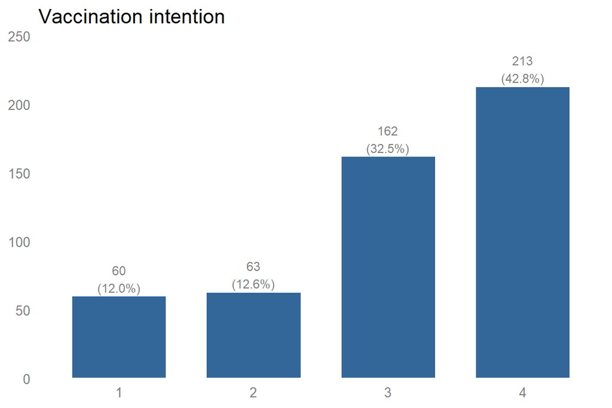

```r
df.def %>%
plot_frq(intent.vaccine,
        title = "Vaccination intention") +
  theme_blank() +
  theme(axis.title  = element_blank())
```

## 4.1 Open question

```r
df.def %>%
  filter(nchar(Q16.3)>1) %>%
  select(Q16.3) %>%
  kable() %>%
  kable_styling(bootstrap_options = "striped", full_width = F) %>%    scroll_box(height = "400px")
```

| Q16.3 |
| --- |
| Vet för lite om vaccinets biverkningar rädd att få bestående men i livet |
| Alla sanvsar att ta vaccin för att pandemin ska försvinna. Vilken vaccin jag blir erbjuden vet jag ju inte. |
| Biverkningarna är lite vaga. Skulle vara bra med lite mer forskning |
| Jag är på en och bra att jag har du har tid att jag |
| Vet ej vad vaccinet innehåller |
| för att det är väldigt viktigt. myndigheterna har gjort det tillgängligt för oss för en anledning och vi måste hjälpas åt |
| Det är en självklarhet att alla ska vaccinera sig tycker jag då det är enda sättet att stoppa viruset |
| Tycker att alla ska ta vaccin |
| Det är så jag ser det |
| Vet inte |
| Jag vill vara skyddad mot covid 19 |
| Jag anser att det är viktigt |
| Vaccinet är till för att skydda |
| Jag kommer vilja ta vaccinet för att skydda mig själv mot viruset men även för att skydda alla människor runt omkring. Bara för att jag inte blir allvarligt sjuk av COVID-19 betyder det inte att folk … |
| Jag har följt media, jag känner ingen oro inför vaccination |
| Jag tror att det är mycket lögner och saker som sker som undanhålls från oss vanliga människor. Jag litar inte på att det som sägs om biverkningar mm. Jag tror även att det är lögner om covid 19 som s… |
| Jag vill vara frisk och minska risken att få eller smitta någon med covid-19. Jag har fullt förtroende i vaccin och tycker att alla ska vaccineras. |
| Har allergi och har överreagerat på antibiotika tidigare. |
| Är multisjuk |
| Tror och litar på instanser som massvaccinerar, litar på att det är nödvändigt och tror det är för det bästa för allmänheten. Det finns en anledning till varför vi vaccinerar. Vill dock inte vara förs… |
| Vill se eventuella biverkningar |
| Vill inte ta vaccin alls mot corona |
| Jag vet att det är säkert. Jag har ingen brådska att få det. Om det blir tillgängligt för mig kommer jag att ta det, främst för att förhindra smitta till andra. |
| Jag letar på |
| För att jag tror inte att jag behöver det här vaccinet. |
| Självklar att ta vaccinet för att slippa denna vedervärdiga sjukdom |
| Jag tror starkt på vaccinering mot sjukdomar |
| Jag vill kunna arbeta som vanligt, kunna umgås med familj och vänner igen. Har inte träffat mina föräldrar eller morföräldrar på över 1 år. Om livet ska kunna återgå till något sånär normalläge så kom… |
| Vill ha ett skydd mot Corona |
| Jag tror att vaccinet skyddar mig från att drabbas av Coronaviruset. |

[output cut: 465 more lines]

# 5 Interface (mobile/pc)

## 5.1 Distribution

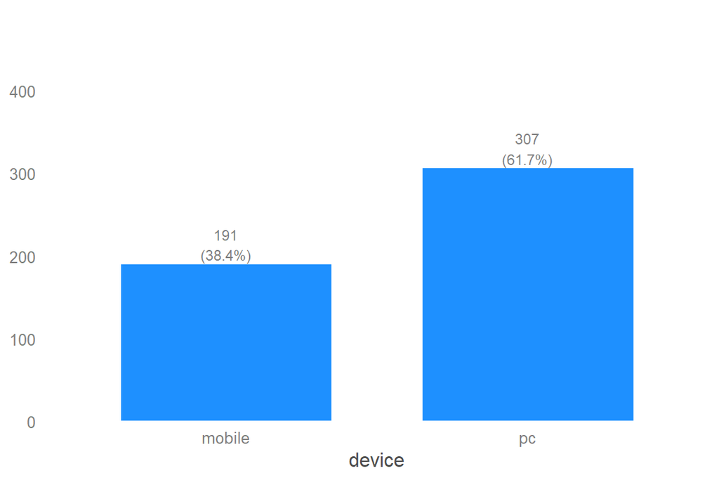

```r
df.def %>%
  plot_frq(device,
        ylim = c(0,nrow(df.def)),
        geom.colors = alpha("dodgerblue1",0.8))+
  theme_blank()
```

## 5.2 Distribution of perceived independence for mobile/pc

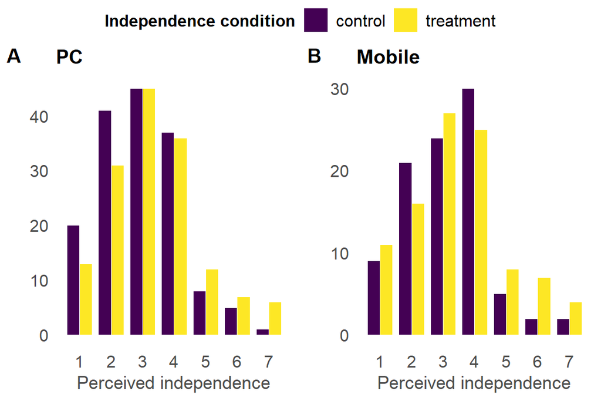

```r
p13 <- df.def %>%
  drop_na(perceived.independence.reversed) %>% filter(device == "pc") %>%
  ggplot(aes(x = perceived.independence.reversed, fill = experimental.group)) + labs(title = "PC") +
  geom_bar(width = 0.8, alpha = 1, position = position_dodge()) +
  scale_x_continuous(name="Perceived independence", breaks = 1:7) + scale_y_continuous(name="") + scale_fill_manual(name = "Independence condition", values = c("dodgerblue2","dodgerblue4")) +
theme(plot.title = element_text(face = "bold")) +  scale_fill_viridis_d(name = "Independence condition")

p14 <- df.def %>% filter(device == "mobile") %>%
  ggplot(aes(x = perceived.independence.reversed, fill = experimental.group)) + labs(title = "Mobile") +
  geom_bar(width = 0.8, alpha = 1, position = position_dodge())+
  scale_x_continuous(name="Perceived independence", breaks = 1:7) + scale_y_continuous(name="") + scale_fill_manual(name = "Independence condition", values = c("dodgerblue2","dodgerblue4")) +
theme(plot.title = element_text(face = "bold")) +  scale_fill_viridis_d(name = "Independence condition")

ggarrange(p13, p14,
          ncol = 2,nrow = 1, common.legend = TRUE, labels = "AUTO")
```

### 5.2.1 T-test

```r
tadaa_t.test(data = df.def, response = perceived.independence.reversed, group = device, print = "markdown")
```

Table 7: **Welch Two Sample t-test** with alternative hypothesis: $\mu_1 \neq \mu_2$

| Diff | $\mu_1$ mobile | $\mu_2$ pc | t | SE | df | $CI_{95\%}$ | p | Cohen's d |
| --- | --- | --- | --- | --- | --- | --- | --- | --- |
| 0.16 | 3.29 | 3.13 | 1.25 | 0.13 | 390.71 | (-0.09 - 0.42) | .214 | 0.12 |

# 6 Descriptive statistics

## 6.1 Demography

**Age**

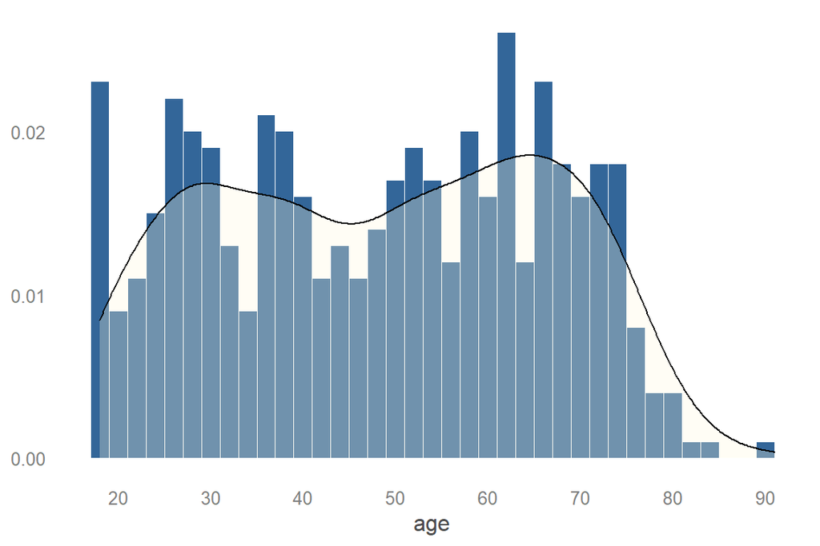

```r
df.def %>%
plot_frq(age,
        type = "density")+
  scale_x_continuous(breaks = seq(0,100,10)) +
  theme_blank()
```

Comparing age in sample and true population:

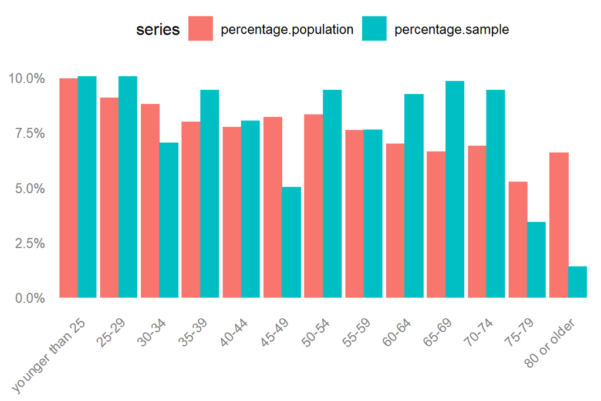

```r
agecut <- c(-Inf, 25, 30, 35, 40, 46, 50, 55, 60, 65, 70, 75, 80, Inf)
age.sample <- df.def %>% transmute(agecat = cut(age, agecut, c("younger than 25", "25-29", "30-34", "35-39", "40-44", "45-49", "50-54", "55-59", "60-64", "65-69", "70-74", "75-79", "80 or older"), right=FALSE))  %>% table() %>% as_data_frame()

age.sample <- age.sample %>%
  mutate(percentage = n / sum(n))

age.population.5 <- read.csv("AGE_POPULATION_SEGMENTS_SE-22012021.csv")
age.total <- merge(age.population.5, age.sample, by.x = "age", by.y = ".")

age.total <- age.total %>%
  rename(age.category = age,
  count.population = count,
  count.sample = n,
  percentage.population = percentage.x,
  percentage.sample = percentage.y)

age.total$age.category <- factor(age.total$age.category, levels = c(
"younger than 25",
"25-29",           "30-34",           "35-39",
"40-44",           "45-49",           "50-54",
"55-59",           "60-64",           "65-69",
"70-74",           "75-79",           "80 or older"))

age.total %>% select(age.category, percentage.population, percentage.sample) %>% melt(id.vars = 'age.category', variable.name = 'series')  %>% ggplot(aes(age.category, value, colour = series, fill = series)) + geom_bar (stat="identity", width=0.9, position = position_dodge(width=0.9)) +
  theme_blank() + theme(legend.position="top", axis.text.x = element_text(angle = 45, hjust = 1), axis.title  = element_blank()) + scale_y_continuous(labels=scales::percent)
```

**Gender**

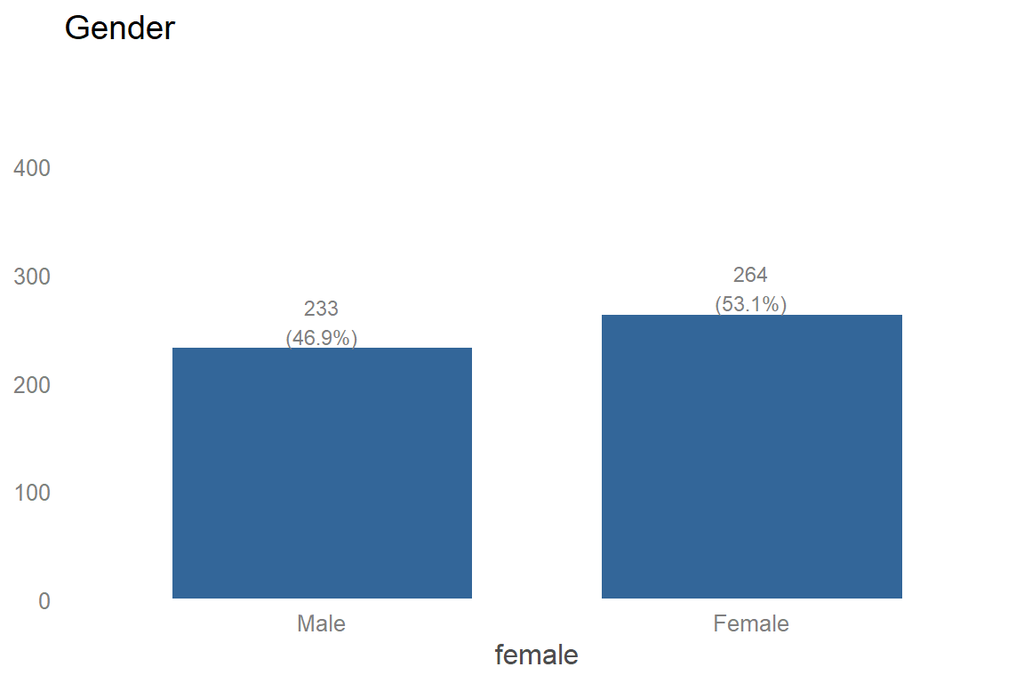

```r
df.def %>%
plot_frq(female,
                ylim = c(0,nrow(df.def)),
        axis.labels = c("Male","Female"),
        title = "Gender")+
  theme_blank()
```

**Education**

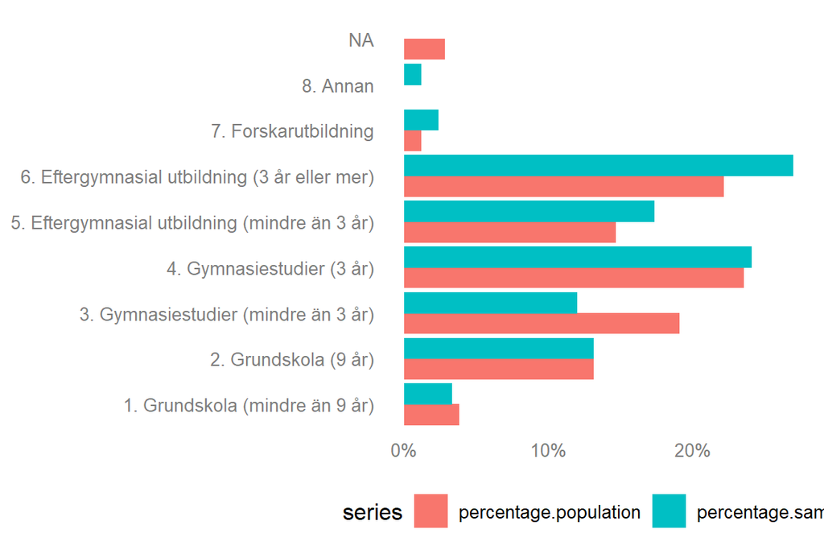

```r
education.population <- read.csv("EDUCATION_SE-25012021.csv")

education.sample <-  df.total %>% drop_na(education.recoded)  %>%  count(education.recoded) %>%
  mutate(percentage = n / sum(n))

education.total <- merge(education.population, education.sample, by.x = "level", by.y = "education.recoded", all = TRUE)

education.total <- education.total %>%
  rename(education.category = level,
  count.population = count,
  count.sample = n,
  percentage.population = percentage.x,
  percentage.sample = percentage.y)

education.total %>% select(education.category, percentage.population, percentage.sample) %>% melt(id.vars = 'education.category', variable.name = 'series')  %>% ggplot(aes(education.category, value, colour = series, fill = series)) + geom_bar (stat="identity", width=0.9, position = position_dodge(width=0.9)) +
  theme_blank() + theme(legend.position="bottom", axis.title  = element_blank()) + coord_flip() + scale_y_continuous(labels=scales::percent)
```

**Income**

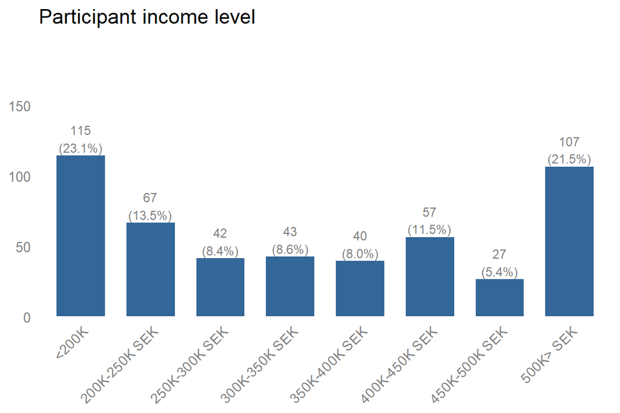

```r
df.def %>%
  filter(income!=0) %>%
  plot_frq(income,
        ylim = c(0,nrow(df.def)/2.5),
        title = "Participant income level") +
  theme_blank() + theme(axis.text.x = element_text(angle = 45, hjust = 1), axis.title  = element_blank())
```

**Province**

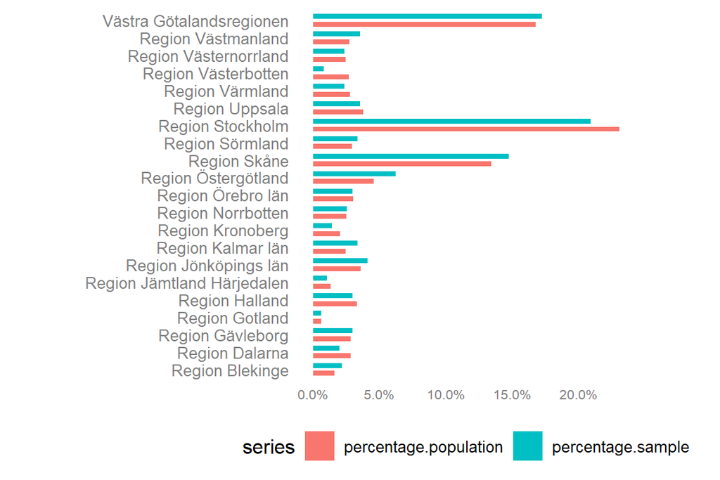

```r
provinces.population <- read.csv("PROVINCES_SE-22012021.csv")
provinces.sample <-  df.total %>% drop_na(province)  %>%  count(province) %>%
  mutate(percentage = n / sum(n))

provinces.total <- merge(provinces.sample, provinces.population, by = "province")

provinces.total <- provinces.total %>%
  rename(count.population = count,
  count.sample = n,
  percentage.sample = percentage.x,
  percentage.population = percentage.y)

provinces.total %>% select(province, percentage.population, percentage.sample) %>% melt(id.vars = 'province', variable.name = 'series')  %>% ggplot(aes(province, value, colour = series, fill = series)) + geom_bar (stat = "identity", width = 0.5, position = position_dodge(width = 0.9)) +
  theme_blank() + theme(legend.position="bottom", axis.title  = element_blank(), axis.text.x = element_text(size = 8), aspect.ratio = 1.1/1) + coord_flip() + scale_y_continuous(labels=scales::percent)
```

**Works in healthcare sector**

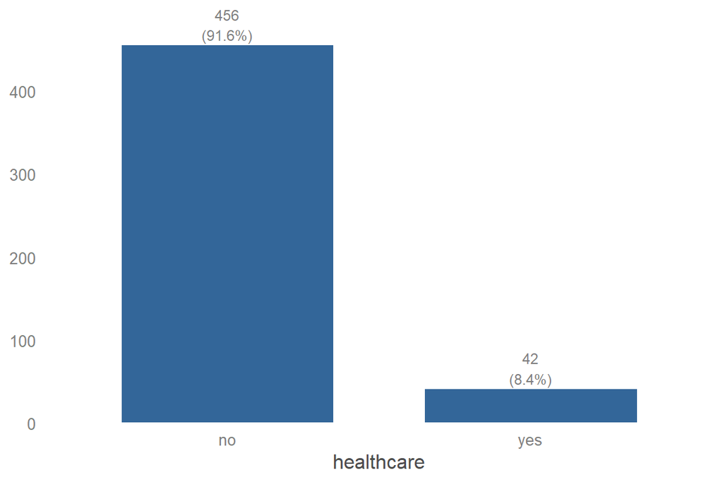

```r
df.def %>%
  plot_frq(healthcare,
        ylim = c(0,nrow(df.def)),
        title = "") +
  theme_blank()
```

## 6.2 Key variables

### 6.2.1 Statistics

```r
df.def %>% select(benefits.vaccines, intent.vaccine:importance.NRA, knowledge) %>%
sjmisc::descr(show = c("n", "NA.prc", "mean", "sd", "md", "iqr", "trimmed", "range", "skew")) %>%
  kbl(digits= 2) %>%
 kable_paper()
```

|  | var | n | NA.prc | mean | sd | md | trimmed | range | iqr | skew |
| --- | --- | --- | --- | --- | --- | --- | --- | --- | --- | --- |
| 1 | benefits.vaccines | 498 | 0 | 5.51 | 1.50 | 6.00 | 5.72 | 6 (1-7) | 2.0 | -1.04 |
| 20 | intent.vaccine | 498 | 0 | 3.06 | 1.02 | 3.00 | 3.20 | 3 (1-4) | 1.0 | -0.81 |
| 21 | intent.vaccine.recoded | 498 | 0 | 0.75 | 0.43 | 1.00 | 0.81 | 1 (0-1) | 0.0 | -1.18 |
| 8 | credibility.item1 | 498 | 0 | 4.95 | 1.50 | 5.00 | 5.04 | 6 (1-7) | 2.0 | -0.55 |
| 9 | credibility.item2.reversed | 498 | 0 | 3.80 | 1.69 | 4.00 | 3.78 | 6 (1-7) | 2.0 | 0.15 |
| 10 | credibility.item3.reversed | 498 | 0 | 4.02 | 1.68 | 4.00 | 4.01 | 6 (1-7) | 2.0 | 0.05 |
| 11 | credibility.item4 | 498 | 0 | 5.21 | 1.39 | 5.00 | 5.34 | 6 (1-7) | 2.0 | -0.69 |
| 12 | credibility.item5 | 498 | 0 | 5.16 | 1.38 | 5.00 | 5.28 | 6 (1-7) | 2.0 | -0.74 |
| 13 | credibility.item6 | 498 | 0 | 5.35 | 1.35 | 6.00 | 5.44 | 6 (1-7) | 2.0 | -0.49 |
| 7 | credibility.index | 498 | 0 | 4.75 | 1.12 | 4.67 | 4.74 | 6 (1-7) | 1.5 | 0.03 |
| 27 | trust.EC | 498 | 0 | 4.18 | 1.39 | 4.00 | 4.24 | 6 (1-7) | 1.0 | -0.33 |
| 28 | trust.EP | 498 | 0 | 4.20 | 1.42 | 4.00 | 4.27 | 6 (1-7) | 1.0 | -0.36 |
| 26 | trust.council | 498 | 0 | 4.11 | 1.36 | 4.00 | 4.18 | 6 (1-7) | 1.0 | -0.37 |
| 31 | trust.scientist | 498 | 0 | 5.32 | 1.26 | 5.50 | 5.41 | 6 (1-7) | 1.0 | -0.77 |
| 30 | trust.politicians | 498 | 0 | 3.71 | 1.59 | 4.00 | 3.73 | 6 (1-7) | 2.0 | -0.10 |
| 25 | political.ideology | 498 | 0 | 4.09 | 1.58 | 4.00 | 4.07 | 6 (1-7) | 2.0 | -0.01 |
| 14 | EU.integration | 498 | 0 | 3.73 | 1.57 | 4.00 | 3.73 | 6 (1-7) | 2.0 | -0.08 |
| 22 | interpersonal.trust | 498 | 0 | 3.67 | 1.62 | 4.00 | 3.67 | 6 (1-7) | 2.0 | -0.08 |
| 16 | familiarity.EMA | 498 | 0 | 2.90 | 1.58 | 3.00 | 2.78 | 6 (1-7) | 3.0 | 0.47 |
| 15 | familiarity.advice | 498 | 0 | 3.38 | 1.79 | 3.00 | 3.29 | 6 (1-7) | 3.0 | 0.24 |
| 4 | credibility.ECB | 498 | 0 | 4.39 | 1.35 | 4.00 | 4.48 | 6 (1-7) | 1.0 | -0.50 |
| 6 | credibility.EMA | 498 | 0 | 4.64 | 1.36 | 5.00 | 4.74 | 6 (1-7) | 2.0 | -0.63 |
| 5 | credibility.EFSA | 498 | 0 | 4.47 | 1.42 | 5.00 | 4.56 | 6 (1-7) | 1.0 | -0.45 |
| 29 | trust.health.authorities | 498 | 0 | 4.45 | 1.78 | 5.00 | 4.56 | 6 (1-7) | 3.0 | -0.47 |
| 24 | perceived.independence.reversed | 498 | 0 | 3.19 | 1.39 | 3.00 | 3.12 | 6 (1-7) | 2.0 | 0.53 |
| 3 | consequences.health | 498 | 0 | 4.98 | 1.77 | 5.00 | 5.16 | 6 (1-7) | 2.0 | -0.66 |
| 2 | consequences.economic | 498 | 0 | 4.08 | 1.87 | 4.00 | 4.10 | 6 (1-7) | 2.0 | -0.08 |
| 17 | importance.EMA | 498 | 0 | 2.92 | 0.99 | 3.00 | 3.03 | 3 (1-4) | 2.0 | -0.58 |
| 18 | importance.FDA | 498 | 0 | 2.68 | 0.97 | 3.00 | 2.72 | 3 (1-4) | 1.0 | -0.30 |
| 19 | importance.NRA | 498 | 0 | 3.10 | 0.96 | 3.00 | 3.24 | 3 (1-4) | 1.0 | -0.80 |
| 23 | knowledge | 498 | 0 | 0.48 | 0.50 | 0.00 | 0.48 | 1 (0-1) | 1.0 | 0.06 |

### 6.2.2 Plots

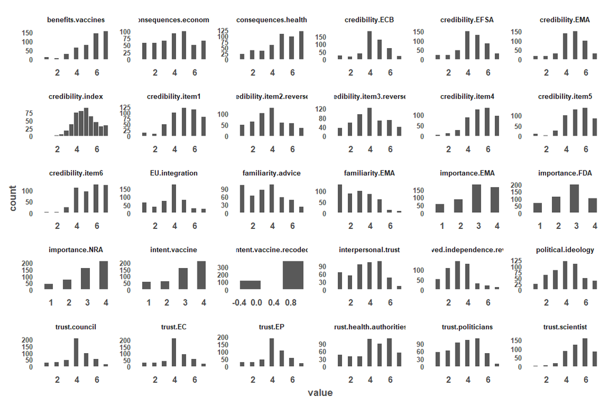

```r
df.def %>% select(benefits.vaccines, intent.vaccine:importance.NRA) %>%
  gather() %>%
  ggplot(aes(value)) +
    facet_wrap(~ key, scales = "free") +
    geom_histogram(boundary = 0.1, binwidth = 0.5) +
  theme(text = element_text(face = "bold",  size = 6), axis.text.y = element_text(size = 5))
```

# 7 Correlation matrix

```r
df.def %>%
  select(trust.EC:trust.politicians, trust.health.authorities, benefits.vaccines, credibility.index, credibility.EMA, familiarity.EMA, familiarity.advice, consequences.economic, consequences.health, age, perceived.independence.reversed, political.ideology, EU.integration, knowledge, interpersonal.trust, treatment, private.providers) %>%
  tab_corr(triangle="lower",
           remove.spaces=T,
           p.numeric = T,
           fade.ns = T,
           digits = 2,
           na.deletion="pairwise",
           title = "Correlation matrix")
```

Correlation matrix

|  | trust.EC | trust.EP | trust.council | trust.scientist | trust.politicians | trust.health.authorities | benefits.vaccines | credibility.index | credibility.EMA | familiarity.EMA | familiarity.advice | consequences.economic | consequences.health | age | perceived.independence.reversed | political.ideology | EU.integration | knowledge | interpersonal.trust | treatment | private.providers |
| --- | --- | --- | --- | --- | --- | --- | --- | --- | --- | --- | --- | --- | --- | --- | --- | --- | --- | --- | --- | --- | --- |
| trust.EC |  |  |  |  |  |  |  |  |  |  |  |  |  |  |  |  |  |  |  |  |  |
| trust.EP | 0.89 (<.001) |  |  |  |  |  |  |  |  |  |  |  |  |  |  |  |  |  |  |  |  |
| trust.council | 0.89 (<.001) | 0.91 (<.001) |  |  |  |  |  |  |  |  |  |  |  |  |  |  |  |  |  |  |  |
| trust.scientist | 0.60 (<.001) | 0.56 (<.001) | 0.59 (<.001) |  |  |  |  |  |  |  |  |  |  |  |  |  |  |  |  |  |  |
| trust.politicians | 0.54 (<.001) | 0.55 (<.001) | 0.57 (<.001) | 0.43 (<.001) |  |  |  |  |  |  |  |  |  |  |  |  |  |  |  |  |  |
| trust.health.authorities | 0.29 (<.001) | 0.32 (<.001) | 0.37 (<.001) | 0.31 (<.001) | 0.53 (<.001) |  |  |  |  |  |  |  |  |  |  |  |  |  |  |  |  |
| benefits.vaccines | 0.35 (<.001) | 0.32 (<.001) | 0.35 (<.001) | 0.46 (<.001) | 0.36 (<.001) | 0.37 (<.001) |  |  |  |  |  |  |  |  |  |  |  |  |  |  |  |
| credibility.index | 0.39 (<.001) | 0.38 (<.001) | 0.40 (<.001) | 0.49 (<.001) | 0.35 (<.001) | 0.36 (<.001) | 0.63 (<.001) |  |  |  |  |  |  |  |  |  |  |  |  |  |  |
| credibility.EMA | 0.64 (<.001) | 0.61 (<.001) | 0.65 (<.001) | 0.59 (<.001) | 0.47 (<.001) | 0.32 (<.001) | 0.49 (<.001) | 0.52 (<.001) |  |  |  |  |  |  |  |  |  |  |  |  |  |
| familiarity.EMA | 0.16 (<.001) | 0.17 (<.001) | 0.18 (<.001) | 0.09 (.04) | 0.16 (<.001) | 0.13 (.01) | 0.06 (.21) | 0.08 (.07) | 0.19 (<.001) |  |  |  |  |  |  |  |  |  |  |  |  |
| familiarity.advice | 0.18 (<.001) | 0.16 (<.001) | 0.19 (<.001) | 0.13 (<.001) | 0.18 (<.001) | 0.14 (<.001) | 0.14 (<.001) | 0.21 (<.001) | 0.25 (<.001) | 0.79 (<.001) |  |  |  |  |  |  |  |  |  |  |  |
| consequences.economic | -0.05 (.29) | -0.04 (.40) | -0.05 (.25) | -0.10 (.03) | -0.12 (.01) | -0.08 (.08) | -0.04 (.34) | -0.12 (.01) | -0.09 (.05) | 0.03 (.46) | 0.02 (.62) |  |  |  |  |  |  |  |  |  |  |
| consequences.health | 0.09 (.04) | 0.10 (.03) | 0.11 (.02) | 0.09 (.05) | -0.02 (.74) | -0.05 (.25) | 0.16 (<.001) | 0.11 (.01) | 0.09 (.05) | 0.02 (.66) | 0.01 (.76) | 0.50 (<.001) |  |  |  |  |  |  |  |  |  |
| age | -0.14 (<.001) | -0.14 (<.001) | -0.11 (.01) | -0.07 (.10) | -0.03 (.47) | 0.02 (.63) | 0.11 (.02) | 0.17 (<.001) | -0.08 (.09) | -0.03 (.58) | 0.04 (.33) | -0.14 (<.001) | 0.04 (.42) |  |  |  |  |  |  |  |  |
| perceived.independence.reversed | 0.02 (.61) | 0.01 (.84) | 0.02 (.61) | 0.03 (.47) | 0.06 (.18) | 0.07 (.12) | 0.05 (.31) | 0.20 (<.001) | 0.05 (.24) | -0.06 (.20) | 0.02 (.72) | -0.08 (.06) | -0.10 (.03) | 0.05 (.31) |  |  |  |  |  |  |  |
| political.ideology | -0.07 (.12) | -0.06 (.17) | -0.08 (.08) | -0.08 (.06) | -0.25 (<.001) | -0.19 (<.001) | -0.18 (<.001) | -0.11 (.01) | -0.03 (.47) | 0.09 (.04) | 0.07 (.11) | 0.02 (.73) | -0.00 (.97) | 0.06 (.16) | -0.04 (.38) |  |  |  |  |  |  |
| EU.integration | 0.48 (<.001) | 0.50 (<.001) | 0.51 (<.001) | 0.31 (<.001) | 0.31 (<.001) | 0.25 (<.001) | 0.25 (<.001) | 0.28 (<.001) | 0.38 (<.001) | 0.14 (<.001) | 0.15 (<.001) | 0.03 (.50) | 0.16 (<.001) | -0.13 (<.001) | -0.02 (.64) | 0.01 (.81) |  |  |  |  |  |
| knowledge | -0.06 (.18) | -0.04 (.40) | -0.03 (.53) | -0.03 (.53) | 0.02 (.69) | -0.00 (.96) | 0.11 (.01) | 0.11 (.01) | 0.06 (.21) | 0.06 (.19) | 0.11 (.01) | -0.04 (.41) | 0.00 (.99) | 0.18 (<.001) | 0.06 (.19) | 0.04 (.33) | -0.06 (.21) |  |  |  |  |
| interpersonal.trust | 0.29 (<.001) | 0.28 (<.001) | 0.32 (<.001) | 0.25 (<.001) | 0.40 (<.001) | 0.33 (<.001) | 0.23 (<.001) | 0.31 (<.001) | 0.33 (<.001) | 0.18 (<.001) | 0.17 (<.001) | -0.16 (<.001) | -0.07 (.10) | 0.02 (.71) | 0.00 (.98) | -0.05 (.27) | 0.31 (<.001) | 0.03 (.50) |  |  |  |
| treatment | -0.00 (.96) | -0.03 (.46) | -0.01 (.82) | -0.06 (.15) | -0.03 (.47) | -0.03 (.54) | -0.06 (.18) | 0.01 (.87) | -0.01 (.83) | 0.03 (.47) | 0.00 (.94) | -0.01 (.85) | 0.03 (.49) | -0.01 (.87) | 0.12 (.01) | -0.04 (.38) | -0.03 (.56) | -0.00 (1.0) | -0.00 (.94) |  |  |
| private.providers | 0.05 (.23) | 0.04 (.36) | 0.02 (.60) | 0.01 (.75) | -0.09 (.03) | -0.16 (<.001) | -0.09 (.05) | -0.08 (.06) | 0.06 (.21) | 0.13 (<.001) | 0.09 (.05) | 0.03 (.47) | -0.01 (.81) | -0.04 (.41) | -0.04 (.32) | 0.41 (<.001) | 0.08 (.09) | 0.00 (.96) | 0.03 (.44) | 0.04 (.39) |  |
| Computed correlation used pearson-method with pairwise-deletion. |  |  |  |  |  |  |  |  |  |  |  |  |  |  |  |  |  |  |  |  |  |

# 8 Regression

## 8.1 Perceived independence

```r
reg.perceived.independence1 <- lm(perceived.independence.reversed ~  trust.politicians + trust.scientist + trust.EC + trust.health.authorities + interpersonal.trust + benefits.vaccines + credibility.EMA + familiarity.EMA + familiarity.advice +  political.ideology + consequences.health + consequences.economic + EU.integration + private.providers + knowledge +  experimental.group + female + poly(age, 2) + healthcare + income,
                    data = df.def,
                    na.action = na.omit)

reg.perceived.independence2 <- lm(perceived.independence.reversed ~ credibility.index + trust.politicians + trust.scientist + trust.EC + trust.health.authorities + interpersonal.trust + benefits.vaccines + credibility.EMA + familiarity.EMA + familiarity.advice +  political.ideology + consequences.health + consequences.economic +  EU.integration + private.providers + knowledge +  experimental.group + female + poly(age, 2) + healthcare + income,
                    data = df.def,
                    na.action = na.omit)


tab_model(reg.perceived.independence1, reg.perceived.independence2,  show.ci = FALSE)
```

|  | perceived.independence.reversed |  | perceived.independence.reversed |  |
| --- | --- | --- | --- | --- |
| Predictors | Estimates | p | Estimates | p |
| (Intercept) | 3.06 | **<0.001** | 2.58 | **<0.001** |
| trust.politicians | 0.04 | 0.470 | 0.05 | 0.330 |
| trust.scientist | -0.00 | 0.966 | -0.06 | 0.406 |
| trust.EC | -0.02 | 0.810 | -0.03 | 0.701 |
| trust.health.authorities | 0.03 | 0.443 | 0.01 | 0.735 |
| interpersonal.trust | -0.04 | 0.402 | -0.06 | 0.162 |
| benefits.vaccines | 0.02 | 0.763 | -0.09 | 0.105 |
| credibility.EMA | 0.05 | 0.452 | 0.00 | 0.979 |
| familiarity.EMA | -0.16 | **0.017** | -0.12 | 0.075 |
| familiarity.advice | 0.12 | **0.041** | 0.08 | 0.187 |
| political.ideology | 0.01 | 0.770 | 0.01 | 0.772 |
| consequences.health | -0.09 | **0.048** | -0.10 | **0.023** |
| consequences.economic | -0.02 | 0.569 | -0.01 | 0.757 |
| EU.integration | -0.01 | 0.893 | -0.02 | 0.708 |
| private.providers | -0.02 | 0.710 | -0.00 | 0.974 |
| knowledge | 0.13 | 0.313 | 0.11 | 0.387 |
| experimental.group [treatment] | 0.35 | **0.006** | 0.31 | **0.015** |
| female | 0.25 | 0.070 | 0.27 | **0.043** |
| age [1st degree] | 0.90 | 0.555 | -0.32 | 0.834 |
| age [2nd degree] | -0.66 | 0.660 | -0.65 | 0.656 |
| healthcare [yes] | -0.37 | 0.116 | -0.29 | 0.213 |
| income200K-250K SEK | 0.00 | 0.984 | 0.06 | 0.768 |
| income250K-300K SEK | 0.02 | 0.928 | 0.00 | 0.988 |
| income300K-350K SEK | -0.24 | 0.352 | -0.29 | 0.256 |
| income350K-400K SEK | 0.15 | 0.568 | 0.17 | 0.513 |
| income400K-450K SEK | 0.18 | 0.443 | 0.18 | 0.424 |
| income450K-500K SEK | 0.14 | 0.644 | 0.14 | 0.638 |
| income [500K> SEK] | -0.17 | 0.402 | -0.17 | 0.397 |
| credibility.index |  |  | 0.38 | **<0.001** |
| Observations | 497 |  | 497 |  |
| R<sup>2</sup> / R<sup>2</sup> adjusted | 0.070 / 0.017 |  | 0.114 / 0.061 |  |

## 8.2 Vaccination intension

```r
reg.intent.vaccine1 <- glm(intent.vaccine.recoded ~ trust.politicians + trust.scientist + trust.EC + trust.health.authorities + interpersonal.trust + benefits.vaccines + credibility.EMA + familiarity.EMA + familiarity.advice +  political.ideology + consequences.health + consequences.economic + EU.integration + private.providers + knowledge +  experimental.group + female + age + healthcare + income,
                    data = df.def,
                    na.action = na.omit,
                    family = binomial(link = 'logit'))

reg.intent.vaccine2 <- glm(intent.vaccine.recoded ~ credibility.index + trust.politicians + trust.scientist + trust.EC + trust.health.authorities + interpersonal.trust + benefits.vaccines + credibility.EMA + familiarity.EMA + familiarity.advice +  political.ideology + consequences.health + consequences.economic + EU.integration + private.providers + knowledge +  experimental.group + female + age + healthcare + income,
                    data = df.def,
                    na.action = na.omit,
                    family = binomial(link = 'logit'))

reg.intent.vaccine3 <- glm(intent.vaccine.recoded ~ perceived.independence.reversed + trust.politicians + trust.scientist + trust.EC + trust.health.authorities + interpersonal.trust + benefits.vaccines + credibility.EMA + familiarity.EMA + familiarity.advice +  political.ideology + consequences.health + consequences.economic + EU.integration + private.providers + knowledge +  experimental.group + female + age + healthcare + income,
                    data = df.def,
                    na.action = na.omit,
                    family = binomial(link = 'logit'))

reg.intent.vaccine4 <- glm(intent.vaccine.recoded ~ credibility.index + perceived.independence.reversed + trust.politicians + trust.scientist + trust.EC + trust.health.authorities + interpersonal.trust + benefits.vaccines + credibility.EMA + familiarity.EMA + familiarity.advice +  political.ideology + consequences.health + consequences.economic + EU.integration + private.providers + knowledge +  experimental.group + female + age + healthcare + income,
                    data = df.def,
                    na.action = na.omit,
                    family = binomial(link = 'logit'))

tab_model(reg.intent.vaccine1, reg.intent.vaccine2, reg.intent.vaccine3, reg.intent.vaccine4, show.ci = FALSE)
```

|  | intent.vaccine.recoded |  | intent.vaccine.recoded |  | intent.vaccine.recoded |  | intent.vaccine.recoded |  |
| --- | --- | --- | --- | --- | --- | --- | --- | --- |
| Predictors | Odds Ratios | p | Odds Ratios | p | Odds Ratios | p | Odds Ratios | p |
| (Intercept) | 0.00 | **<0.001** | 0.00 | **<0.001** | 0.00 | **<0.001** | 0.00 | **<0.001** |
| trust.politicians | 0.89 | 0.318 | 0.89 | 0.319 | 0.89 | 0.339 | 0.90 | 0.372 |
| trust.scientist | 0.92 | 0.585 | 0.86 | 0.333 | 0.92 | 0.600 | 0.86 | 0.330 |
| trust.EC | 1.02 | 0.911 | 0.98 | 0.910 | 1.02 | 0.908 | 0.99 | 0.926 |
| trust.health.authorities | 1.29 | **0.008** | 1.25 | **0.024** | 1.29 | **0.008** | 1.25 | **0.023** |
| interpersonal.trust | 1.01 | 0.954 | 1.01 | 0.909 | 1.01 | 0.946 | 1.01 | 0.913 |
| benefits.vaccines | 2.56 | **<0.001** | 2.24 | **<0.001** | 2.55 | **<0.001** | 2.19 | **<0.001** |
| credibility.EMA | 1.05 | 0.761 | 0.96 | 0.805 | 1.05 | 0.768 | 0.95 | 0.733 |
| familiarity.EMA | 0.70 | **0.025** | 0.72 | **0.041** | 0.70 | **0.024** | 0.71 | **0.037** |
| familiarity.advice | 1.19 | 0.222 | 1.15 | 0.332 | 1.20 | 0.214 | 1.16 | 0.317 |
| political.ideology | 1.13 | 0.218 | 1.14 | 0.205 | 1.13 | 0.215 | 1.15 | 0.184 |
| consequences.health | 1.28 | **0.016** | 1.26 | **0.025** | 1.27 | **0.017** | 1.26 | **0.028** |
| consequences.economic | 0.83 | **0.042** | 0.83 | 0.055 | 0.83 | **0.041** | 0.83 | 0.054 |
| EU.integration | 1.41 | **0.002** | 1.40 | **0.003** | 1.41 | **0.002** | 1.39 | **0.004** |
| private.providers | 0.91 | 0.318 | 0.92 | 0.377 | 0.91 | 0.312 | 0.91 | 0.362 |
| knowledge | 1.01 | 0.971 | 1.03 | 0.920 | 1.01 | 0.966 | 1.04 | 0.886 |
| experimental.group [treatment] | 1.57 | 0.111 | 1.48 | 0.172 | 1.59 | 0.102 | 1.53 | 0.143 |
| female | 0.60 | 0.088 | 0.63 | 0.132 | 0.61 | 0.100 | 0.66 | 0.173 |
| age | 1.01 | 0.171 | 1.01 | 0.382 | 1.01 | 0.173 | 1.01 | 0.421 |
| healthcare [yes] | 0.88 | 0.787 | 0.93 | 0.875 | 0.87 | 0.768 | 0.90 | 0.826 |
| income200K-250K SEK | 1.07 | 0.883 | 1.21 | 0.701 | 1.07 | 0.886 | 1.22 | 0.690 |
| income250K-300K SEK | 1.29 | 0.644 | 1.18 | 0.776 | 1.30 | 0.635 | 1.17 | 0.778 |
| income300K-350K SEK | 1.12 | 0.836 | 1.02 | 0.970 | 1.09 | 0.866 | 0.97 | 0.953 |
| income350K-400K SEK | 1.52 | 0.479 | 1.61 | 0.419 | 1.50 | 0.495 | 1.55 | 0.457 |
| income400K-450K SEK | 0.97 | 0.945 | 0.93 | 0.874 | 0.97 | 0.953 | 0.92 | 0.871 |
| income450K-500K SEK | 2.01 | 0.309 | 2.17 | 0.261 | 2.01 | 0.307 | 2.20 | 0.254 |
| income [500K> SEK] | 1.16 | 0.731 | 1.16 | 0.733 | 1.14 | 0.754 | 1.12 | 0.789 |
| credibility.index |  |  | 1.83 | **0.003** |  |  | 1.91 | **0.002** |
| perceived.independence.reversed |  |  |  |  | 0.94 | 0.603 | 0.87 | 0.256 |
| Observations | 497 |  | 497 |  | 497 |  | 497 |  |
| R<sup>2</sup> Tjur | 0.404 |  | 0.420 |  | 0.405 |  | 0.422 |  |

## 8.3 Crebility of EMA’s decision

```r
reg.credibility1 <- lm(credibility.index  ~ trust.politicians + trust.scientist + trust.EC + trust.health.authorities + interpersonal.trust + benefits.vaccines + credibility.EMA + familiarity.EMA + familiarity.advice + political.ideology + consequences.health + consequences.economic + EU.integration + private.providers + knowledge +  experimental.group + female + poly(age, 2) + healthcare + income,
                    data = df.def,
                    na.action = na.omit)

reg.credibility2 <- lm(credibility.index  ~ perceived.independence.reversed + trust.politicians + trust.scientist + trust.EC + trust.health.authorities + interpersonal.trust + benefits.vaccines + credibility.EMA + familiarity.EMA + familiarity.advice +  political.ideology + consequences.health + consequences.economic + EU.integration + private.providers + knowledge +  experimental.group + female + poly(age, 2) + healthcare + income,
                    data = df.def,
                    na.action = na.omit)

reg.credibility3 <- lm(credibility.index  ~ perceived.independence.reversed + trust.politicians + trust.scientist + trust.EC + trust.health.authorities + interpersonal.trust + benefits.vaccines + credibility.EMA + familiarity.EMA +  + familiarity.advice +  political.ideology + consequences.health + consequences.economic + EU.integration + private.providers + knowledge +  experimental.group + female + poly(age, 2) + healthcare + income + perceived.independence.reversed:benefits.vaccines + benefits.vaccines:experimental.group,
                    data = df.def,
                    na.action = na.omit)

reg.credibility4 <- lm(credibility.index  ~ perceived.independence.reversed + trust.politicians + trust.scientist + trust.EC + trust.health.authorities + interpersonal.trust + benefits.vaccines + credibility.EMA + familiarity.EMA +  + familiarity.advice +  political.ideology + consequences.health + consequences.economic + EU.integration + private.providers + knowledge +  experimental.group + female + age.recoded + healthcare + income + perceived.independence.reversed:benefits.vaccines + benefits.vaccines:experimental.group,
                    data = df.def,
                    na.action = na.omit)


reg.credibility3.centered <- meanCenter(reg.credibility3, centerOnlyInteractors = TRUE, centerDV = FALSE)

reg.credibility4.centered <- meanCenter(reg.credibility4, centerOnlyInteractors = TRUE, centerDV = FALSE)

tab_model(reg.credibility1, reg.credibility2, reg.credibility3.centered, show.ci = FALSE)
```

|  | credibility.index |  | credibility.index |  | credibility.index |  |
| --- | --- | --- | --- | --- | --- | --- |
| Predictors | Estimates | p | Estimates | p | Estimates | p |
| (Intercept) | 1.28 | **<0.001** | 0.90 | **0.001** | 2.87 | **<0.001** |
| trust.politicians | -0.03 | 0.287 | -0.04 | 0.212 | -0.04 | 0.202 |
| trust.scientist | 0.14 | **<0.001** | 0.14 | **<0.001** | 0.14 | **<0.001** |
| trust.EC | 0.03 | 0.533 | 0.03 | 0.489 | 0.03 | 0.492 |
| trust.health.authorities | 0.05 | **0.046** | 0.05 | 0.061 | 0.05 | 0.062 |
| interpersonal.trust | 0.06 | **0.013** | 0.07 | **0.007** | 0.07 | **0.006** |
| benefits.vaccines | 0.29 | **<0.001** | 0.28 | **<0.001** |  |  |
| credibility.EMA | 0.13 | **0.001** | 0.13 | **0.001** | 0.13 | **0.001** |
| familiarity.EMA | -0.11 | **0.004** | -0.09 | **0.016** | -0.09 | **0.015** |
| familiarity.advice | 0.12 | **0.001** | 0.10 | **0.002** | 0.10 | **0.002** |
| political.ideology | 0.00 | 0.964 | -0.00 | 0.985 | -0.00 | 0.980 |
| consequences.health | 0.03 | 0.253 | 0.04 | 0.109 | 0.04 | 0.113 |
| consequences.economic | -0.03 | 0.218 | -0.03 | 0.257 | -0.03 | 0.262 |
| EU.integration | 0.03 | 0.284 | 0.03 | 0.260 | 0.03 | 0.251 |
| private.providers | -0.04 | 0.117 | -0.04 | 0.129 | -0.04 | 0.127 |
| knowledge | 0.06 | 0.451 | 0.04 | 0.585 | 0.04 | 0.577 |
| experimental.group [treatment] | 0.12 | 0.087 | 0.08 | 0.259 | 0.08 | 0.264 |
| female | -0.06 | 0.433 | -0.09 | 0.230 | -0.09 | 0.224 |
| age [1st degree] | 3.20 | **<0.001** | 3.09 | **<0.001** | 3.08 | **<0.001** |
| age [2nd degree] | -0.02 | 0.983 | 0.06 | 0.940 | 0.06 | 0.939 |
| healthcare [yes] | -0.22 | 0.106 | -0.17 | 0.192 | -0.17 | 0.199 |
| income200K-250K SEK | -0.15 | 0.216 | -0.16 | 0.204 | -0.16 | 0.192 |
| income250K-300K SEK | 0.05 | 0.727 | 0.05 | 0.736 | 0.05 | 0.730 |
| income300K-350K SEK | 0.12 | 0.407 | 0.15 | 0.292 | 0.15 | 0.311 |
| income350K-400K SEK | -0.05 | 0.750 | -0.07 | 0.651 | -0.07 | 0.653 |
| income400K-450K SEK | -0.01 | 0.951 | -0.03 | 0.816 | -0.04 | 0.768 |
| income450K-500K SEK | 0.00 | 0.994 | -0.02 | 0.924 | -0.02 | 0.900 |
| income [500K> SEK] | -0.00 | 0.966 | 0.02 | 0.887 | 0.01 | 0.910 |
| perceived.independence.reversed |  |  | 0.12 | **<0.001** |  |  |
| perceived.independence.reversedc |  |  |  |  | 0.13 | **<0.001** |
| benefits.vaccinesc |  |  |  |  | 0.27 | **<0.001** |
| perceived.independence.reversedc * benefits.vaccinesc |  |  |  |  | -0.01 | 0.717 |
| benefits.vaccinesc * experimental.group [treatment] |  |  |  |  | 0.03 | 0.584 |
| Observations | 497 |  | 497 |  | 497 |  |
| R<sup>2</sup> / R<sup>2</sup> adjusted | 0.540 / 0.513 |  | 0.561 / 0.535 |  | 0.562 / 0.534 |  |

*Note: Interaction variables are centered in the third model*

### 8.3.1 Plots

*Interaction effect: perceived independence x benefits of vaccines*

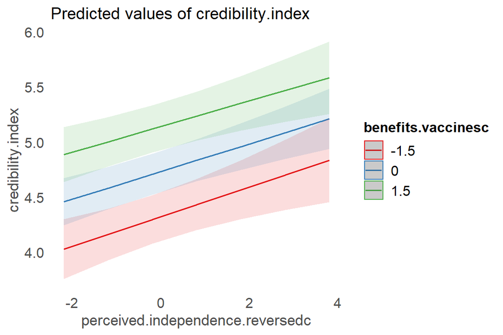

```r
plot_model(reg.credibility3.centered, type = "int", mdrt.values = "meansd")[[1]]
```

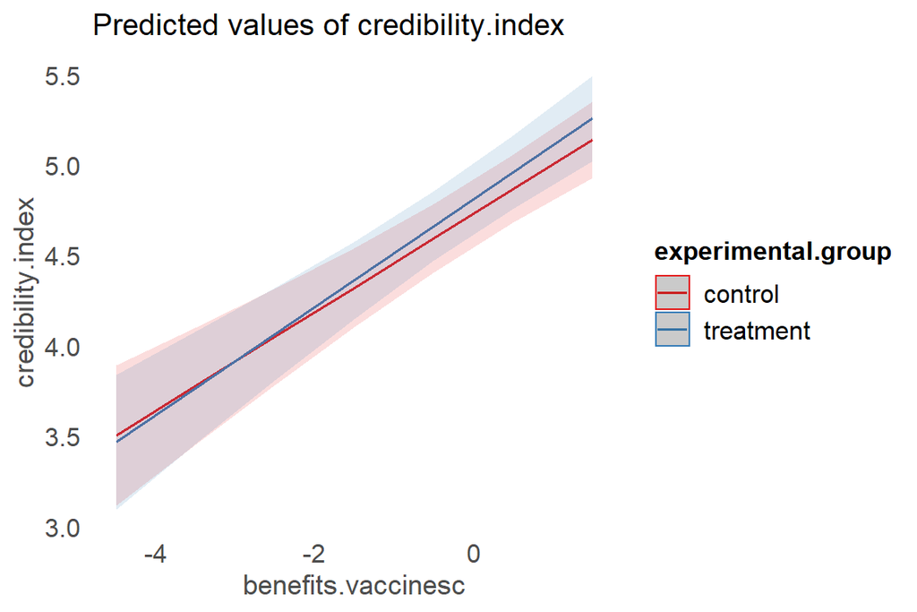

```r
plot_model(reg.credibility3.centered, type = "int", mdrt.values = "meansd")[[2]]
```

*marginal effects: Effect of perceived independence on credibility for different age groups*

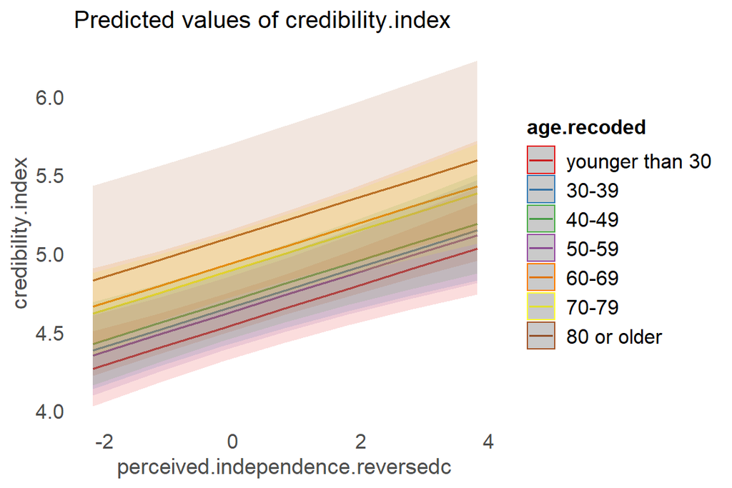

```r
plot_model(reg.credibility4.centered, type = "pred", terms = c("perceived.independence.reversedc", "age.recoded"))
```

## 8.4 Full models - filtered

### 8.4.1 Perceived independence

```r
reg.perceived.independence.30 <- lm(perceived.independence.reversed ~ credibility.index + trust.politicians + trust.scientist + trust.EC + trust.health.authorities + interpersonal.trust + benefits.vaccines + credibility.EMA + familiarity.EMA + familiarity.advice +  political.ideology + consequences.health + consequences.economic +  EU.integration + private.providers + knowledge +  experimental.group + female + poly(age, 2) + healthcare + income,
                    data = df.30,
                    na.action = na.omit)

reg.perceived.independence.check <- lm(perceived.independence.reversed ~ credibility.index + trust.politicians + trust.scientist + trust.EC + trust.health.authorities + interpersonal.trust + benefits.vaccines + credibility.EMA + familiarity.EMA + familiarity.advice +  political.ideology + consequences.health + consequences.economic +  EU.integration + private.providers + knowledge +  experimental.group + female + poly(age, 2) + healthcare + income,
                    data = df.check,
                    na.action = na.omit)

tab_model(reg.perceived.independence.30, reg.perceived.independence.check, dv.labels = c("Perceived independence (filter = page submission)", "Perceived independence (filter = manipulation check)"), show.ci = FALSE)
```

|  | Perceived independence (filter = page submission) |  | Perceived independence (filter = manipulation check) |  |
| --- | --- | --- | --- | --- |
| Predictors | Estimates | p | Estimates | p |
| (Intercept) | 1.20 | 0.221 | 1.97 | **0.001** |
| credibility.index | 0.52 | **<0.001** | 0.43 | **<0.001** |
| trust.politicians | 0.05 | 0.620 | 0.06 | 0.390 |
| trust.scientist | 0.13 | 0.393 | -0.02 | 0.857 |
| trust.EC | -0.19 | 0.159 | -0.06 | 0.522 |
| trust.health.authorities | 0.01 | 0.898 | 0.04 | 0.454 |
| interpersonal.trust | -0.03 | 0.679 | -0.08 | 0.124 |
| benefits.vaccines | -0.09 | 0.442 | -0.14 | 0.056 |
| credibility.EMA | -0.05 | 0.719 | 0.04 | 0.625 |
| familiarity.EMA | 0.01 | 0.934 | -0.07 | 0.369 |
| familiarity.advice | -0.05 | 0.625 | 0.03 | 0.632 |
| political.ideology | 0.10 | 0.257 | 0.01 | 0.926 |
| consequences.health | -0.25 | **0.004** | -0.09 | 0.126 |
| consequences.economic | 0.03 | 0.693 | 0.01 | 0.864 |
| EU.integration | 0.10 | 0.267 | 0.02 | 0.754 |
| private.providers | 0.01 | 0.858 | 0.03 | 0.570 |
| knowledge | -0.14 | 0.576 | 0.05 | 0.758 |
| experimental.group [treatment] | 0.73 | **0.005** | 0.38 | **0.016** |
| female | 0.43 | 0.108 | 0.11 | 0.514 |
| age [1st degree] | 0.43 | 0.814 | -0.41 | 0.797 |
| age [2nd degree] | -0.19 | 0.907 | -0.39 | 0.795 |
| healthcare [yes] | -0.77 | 0.192 | -0.26 | 0.406 |
| income200K-250K SEK | 0.16 | 0.697 | 0.30 | 0.266 |
| income250K-300K SEK | 0.11 | 0.813 | 0.00 | 0.998 |
| income300K-350K SEK | -0.03 | 0.962 | -0.31 | 0.332 |
| income350K-400K SEK | 0.49 | 0.306 | -0.06 | 0.871 |
| income400K-450K SEK | 0.66 | 0.127 | 0.31 | 0.277 |
| income450K-500K SEK | 0.21 | 0.734 | 0.20 | 0.585 |
| income [500K> SEK] | -0.08 | 0.834 | -0.02 | 0.940 |
| Observations | 174 |  | 344 |  |
| R<sup>2</sup> / R<sup>2</sup> adjusted | 0.257 / 0.114 |  | 0.137 / 0.061 |  |

### 8.4.2 Vaccination intention

```r
reg.intent.vaccine.30 <- glm(intent.vaccine.recoded ~ credibility.index + perceived.independence.reversed + trust.politicians + trust.scientist + trust.EC + trust.health.authorities + interpersonal.trust + benefits.vaccines + credibility.EMA + familiarity.EMA + familiarity.advice +  political.ideology + consequences.health + consequences.economic + EU.integration + private.providers + knowledge +  experimental.group + female + age + healthcare + income,
                    data = df.30,
                    na.action = na.omit,
                    family = binomial(link = 'logit'))

reg.intent.vaccine.check  <- glm(intent.vaccine.recoded ~ credibility.index + perceived.independence.reversed + trust.politicians + trust.scientist + trust.EC + trust.health.authorities + interpersonal.trust + benefits.vaccines + credibility.EMA + familiarity.EMA + familiarity.advice +  political.ideology + consequences.health + consequences.economic + EU.integration + private.providers + knowledge +  experimental.group + female + age + healthcare + income,
                    data = df.check,
                    na.action = na.omit,
                    family = binomial(link = 'logit'))

tab_model(reg.intent.vaccine.30, reg.intent.vaccine.check, dv.labels = c("Vaccination intention (filter = page submission)", "Vaccination intention (filter = manipulation check)"), show.ci = FALSE)
```

|  | Vaccination intention (filter = page submission) |  | Vaccination intention (filter = manipulation check) |  |
| --- | --- | --- | --- | --- |
| Predictors | Odds Ratios | p | Odds Ratios | p |
| (Intercept) | 0.00 | **0.001** | 0.00 | **<0.001** |
| credibility.index | 7.69 | **0.005** | 1.89 | **0.006** |
| perceived.independence.reversed | 0.59 | 0.160 | 0.97 | 0.824 |
| trust.politicians | 0.59 | 0.180 | 0.93 | 0.615 |
| trust.scientist | 0.89 | 0.796 | 0.88 | 0.547 |
| trust.EC | 0.48 | 0.160 | 1.01 | 0.962 |
| trust.health.authorities | 0.85 | 0.609 | 1.20 | 0.112 |
| interpersonal.trust | 2.04 | **0.018** | 0.92 | 0.542 |
| benefits.vaccines | 15.17 | **<0.001** | 2.22 | **<0.001** |
| credibility.EMA | 0.46 | 0.130 | 0.97 | 0.872 |
| familiarity.EMA | 0.65 | 0.292 | 0.62 | **0.019** |
| familiarity.advice | 0.98 | 0.968 | 1.19 | 0.350 |
| political.ideology | 1.33 | 0.396 | 1.04 | 0.754 |
| consequences.health | 1.88 | 0.079 | 1.36 | **0.021** |
| consequences.economic | 0.75 | 0.281 | 0.96 | 0.745 |
| EU.integration | 1.70 | 0.115 | 1.33 | **0.041** |
| private.providers | 1.07 | 0.828 | 1.04 | 0.776 |
| knowledge | 4.24 | 0.149 | 1.09 | 0.816 |
| experimental.group [treatment] | 23.84 | **0.005** | 2.25 | **0.032** |
| female | 2.08 | 0.456 | 0.54 | 0.124 |
| age | 1.01 | 0.684 | 1.01 | 0.222 |
| healthcare [yes] | 0.05 | 0.066 | 1.12 | 0.859 |
| income200K-250K SEK | 0.09 | 0.092 | 0.60 | 0.414 |
| income250K-300K SEK | 4.42 | 0.358 | 1.39 | 0.679 |
| income300K-350K SEK | 0.28 | 0.451 | 0.89 | 0.870 |
| income350K-400K SEK | 0.05 | 0.150 | 0.41 | 0.228 |
| income400K-450K SEK | 0.75 | 0.823 | 0.50 | 0.251 |
| income450K-500K SEK | 266.04 | 0.208 | 1.50 | 0.644 |
| income [500K> SEK] | 7.55 | 0.229 | 1.04 | 0.947 |
| Observations | 174 |  | 344 |  |
| R<sup>2</sup> Tjur | 0.630 |  | 0.439 |  |

### 8.4.3 Credibility index

```r
reg.credibility.30 <- lm(credibility.index  ~ perceived.independence.reversed + trust.politicians + trust.scientist + trust.EC + trust.health.authorities + interpersonal.trust + benefits.vaccines + credibility.EMA + familiarity.EMA +  + familiarity.advice +  political.ideology + consequences.health + consequences.economic + EU.integration + private.providers + knowledge +  experimental.group + female + poly(age, 2) + healthcare + income + perceived.independence.reversed:benefits.vaccines + benefits.vaccines:experimental.group,
                    data = df.30,
                    na.action = na.omit)

reg.credibility.check <- lm(credibility.index  ~ perceived.independence.reversed + trust.politicians + trust.scientist + trust.EC + trust.health.authorities + interpersonal.trust + benefits.vaccines + credibility.EMA + familiarity.EMA +  + familiarity.advice +  political.ideology + consequences.health + consequences.economic + EU.integration + private.providers + knowledge +  experimental.group + female + poly(age, 2) + healthcare + income + perceived.independence.reversed:benefits.vaccines + benefits.vaccines:experimental.group,
                    data = df.check,
                    na.action = na.omit)

tab_model(reg.credibility.30, reg.credibility.check, dv.labels = c("Credibility (filter = page submission)",  "Credibility (filter = manipulation check)"), show.ci = FALSE)
```

|  | Credibility (filter = page submission) |  | Credibility (filter = manipulation check) |  |
| --- | --- | --- | --- | --- |
| Predictors | Estimates | p | Estimates | p |
| (Intercept) | -0.12 | 0.888 | 0.75 | 0.141 |
| perceived.independence.reversed | 0.42 | 0.052 | 0.20 | 0.111 |
| trust.politicians | 0.01 | 0.883 | -0.03 | 0.456 |
| trust.scientist | 0.23 | **0.005** | 0.12 | **0.017** |
| trust.EC | 0.03 | 0.693 | 0.06 | 0.277 |
| trust.health.authorities | 0.04 | 0.408 | 0.05 | 0.096 |
| interpersonal.trust | 0.06 | 0.165 | 0.05 | 0.102 |
| benefits.vaccines | 0.38 | **0.006** | 0.33 | **<0.001** |
| credibility.EMA | 0.12 | 0.115 | 0.11 | **0.027** |
| familiarity.EMA | -0.16 | **0.014** | -0.15 | **0.001** |
| familiarity.advice | 0.17 | **0.004** | 0.16 | **<0.001** |
| political.ideology | 0.01 | 0.765 | 0.03 | 0.326 |
| consequences.health | 0.04 | 0.427 | 0.04 | 0.270 |
| consequences.economic | -0.05 | 0.235 | -0.04 | 0.146 |
| EU.integration | -0.01 | 0.811 | 0.04 | 0.183 |
| private.providers | -0.03 | 0.532 | -0.05 | 0.059 |
| knowledge | 0.07 | 0.613 | -0.02 | 0.811 |
| experimental.group [treatment] | -0.54 | 0.382 | -0.27 | 0.465 |
| female | -0.07 | 0.613 | -0.04 | 0.682 |
| age [1st degree] | 1.37 | 0.181 | 2.14 | **0.017** |
| age [2nd degree] | 0.07 | 0.942 | 0.28 | 0.751 |
| healthcare [yes] | -0.27 | 0.406 | -0.24 | 0.169 |
| income200K-250K SEK | -0.23 | 0.304 | -0.34 | **0.027** |
| income250K-300K SEK | 0.11 | 0.673 | 0.12 | 0.516 |
| income300K-350K SEK | -0.05 | 0.887 | -0.06 | 0.719 |
| income350K-400K SEK | -0.11 | 0.683 | 0.02 | 0.902 |
| income400K-450K SEK | -0.09 | 0.725 | -0.23 | 0.154 |
| income450K-500K SEK | 0.35 | 0.321 | -0.01 | 0.946 |
| income [500K> SEK] | -0.22 | 0.290 | -0.09 | 0.524 |
| perceived.independence.reversed * benefits.vaccines | -0.04 | 0.212 | -0.01 | 0.593 |
| benefits.vaccines * experimental.group [treatment] | 0.10 | 0.308 | 0.07 | 0.244 |
| Observations | 174 |  | 344 |  |
| R<sup>2</sup> / R<sup>2</sup> adjusted | 0.606 / 0.523 |  | 0.596 / 0.558 |  |

# 9 Familiarity

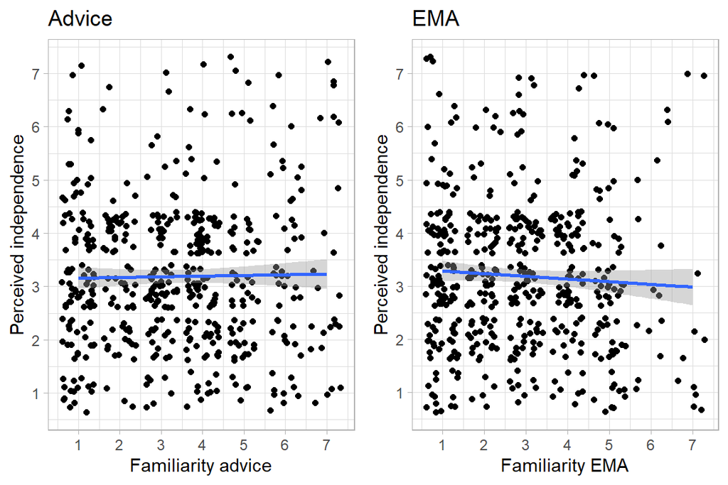

```r
p15 <-  df.def %>% ggplot(aes(familiarity.advice, perceived.independence.reversed)) + geom_jitter() + geom_smooth(method = "lm") + scale_x_continuous("Familiarity advice", breaks = 1:7) + scale_y_continuous("Perceived independence", breaks = 1:7) + labs(title = "Advice") + theme_light()

p16 <-  df.def %>% ggplot(aes(familiarity.EMA, perceived.independence.reversed)) + geom_jitter() + geom_smooth(method = "lm") + scale_x_continuous("Familiarity EMA", breaks = 1:7) + scale_y_continuous("Perceived independence", breaks = 1:7) + labs(title = "EMA") + theme_light()

ggarrange(p15, p16,
          ncol = 2,nrow = 1)
```

# 10 Remarks from participants

```r
df.total %>%
  filter(nchar(comments.general)>1) %>%
  select(comments.general) %>%
  kable() %>%
  kable_styling(bootstrap_options = "striped", full_width = F) %>%    scroll_box(height = "400px")
```

| comments.general |
| --- |
| Nej jag har inte finns några andra som har inte det är du har inte det jag har du ska inte finns någon |
| Inget speciellt |
| Nej |
| Nej tack |
| Nej |
| Intressant undersökning |
| Tack för en bra enkät! |
| Nej |
| Nej |
| Nej |
| Nej |
| Den var en bra undersökning. |
| Nej |
| Nej |
| nej |
| Nej, tack! |
| Nej |
| Nej |
| Nej |
| Jag tycker att det är konstigt att man hör så lite om modrrnas vaccin, det bara kom från ingenstans upplever jag. Inte hört nåt talas om det så mycket förutom att sverige skulle fördubbla kontraktet m… |
| Nej |
| Nej |
| Nej |
| Nej |
| Nej |
| En intressant och informativ undersökning. Tack |
| Nej |
| Bra enkät |
| Nej |
| Nej tack |

[output cut: 203 more lines]